# Week 6 HW

Tyler Jackson

5/6/2019

# Setup

Libraries

```r
library(rspatial)
library(raster)
library(sp)
library(spdep)
library(spgwr)
library(gstat)
library(fields)
library(dismo)
library(rgdal)
```

# Monday

California House Price Data

We will use house prices data from the 1990 census, taken from “Pace, R.K. and R. Barry, 1997. Sparse Spatial Autoregressions. Statistics and Probability Letters 33: 291-297.”

```r
#load housing data from rspatial
houses <- sp_data("houses1990.csv")
#load county data for mapping
counties <- sp_data('counties')

#check it out
dim(houses)
```

```
## [1] 20640     9
```

```r
head(houses)
```

```
##   houseValue income houseAge rooms bedrooms population households latitude
## 1     452600 8.3252       41   880      129        322        126    37.88
## 2     358500 8.3014       21  7099     1106       2401       1138    37.86
## 3     352100 7.2574       52  1467      190        496        177    37.85
## 4     341300 5.6431       52  1274      235        558        219    37.85
## 5     342200 3.8462       52  1627      280        565        259    37.85
## 6     269700 4.0368       52   919      213        413        193    37.85
##   longitude
## 1   -122.23
## 2   -122.22
## 3   -122.24
## 4   -122.25
## 5   -122.25
## 6   -122.25
```

Each record represents a census “blockgroup”. The longitude and latitude of the centroids of each block group are available. We can use that to make a map and we can also use these to link the data to other spatial data. For example to get county-membership of each block group. To do that, let’s first turn this into a SpatialPointsDataFrame to find out to which county each point belongs.

```r
#use coordinates to turn into an sp object
#since houses df already has lon/lat this is pretty easy
coordinates(houses) <- ~longitude+latitude
```

Now get the county boundaries and assign CRS of the houses data matches that of the counties (because they are both in longitude/latitude!).

```r
#match our crs in the new SP object to the counties
crs(houses) <- crs(counties)
```

Do a spatial query (points in polygon)

```r
#get which county each hous is in by row
cnty <- over(houses, counties)
head(cnty)
```

```
##   STATE COUNTY    NAME LSAD LSAD_TRANS
## 1    06    001 Alameda   06     County
## 2    06    001 Alameda   06     County
## 3    06    001 Alameda   06     County
## 4    06    001 Alameda   06     County
## 5    06    001 Alameda   06     County
## 6    06    001 Alameda   06     County
```

Summarize

We can summarize the data by county. First combine the extracted county data with the original data.

```r
#join the county info to the houses df
hd <- cbind(data.frame(houses), cnty)
```

Compute the population by county

```r
#this gets the population and sums it by NAME, outputs an array
totpop <- tapply(hd$population, hd$NAME, sum)
head(totpop)
```

```
##   Alameda    Alpine    Amador     Butte Calaveras    Colusa
##   1241779      1113     30039    182120     31998     16275
```

Income is harder because we have the median household income by blockgroup. But it can be approximated by first computing total income by blockgroup, summing that, and dividing that by the total number of households.

```r
# total income
hd$suminc <- hd$income * hd$households

# now use aggregate (similar to tapply), outputs a df
csum <- aggregate(hd[, c('suminc', 'households')], list(hd$NAME), sum)

# divide total income by number of households
csum$income <- 10000 * csum$suminc / csum$households

# sort
csum <- csum[order(csum$income), ]
head(csum)
```

```
##     Group.1    suminc households   income
## 53  Trinity 11198.985       5156 21720.30
## 58     Yuba 43739.708      19882 21999.65
## 25    Modoc  8260.597       3711 22259.76
## 47 Siskiyou 38769.952      17302 22407.79
## 17     Lake 47612.899      20805 22885.32
## 11    Glenn 20497.683       8821 23237.37
```

```r
tail(csum)
```

```
##         Group.1    suminc households   income
## 56      Ventura  994094.8     210418 47243.81
## 7  Contra Costa 1441734.6     299123 48198.72
## 30       Orange 3938638.1     800968 49173.48
## 43  Santa Clara 2621895.6     518634 50553.87
## 41    San Mateo 1169145.6     230674 50683.89
## 21        Marin  436808.4      85869 50869.17
```

Regression

Before we make a regression model, let’s first add some new variables that we might use, and then see if we can build a regression model with house price as dependent variable. The authors of the paper used a lot of log tranforms, so you can also try that.

```r
#create rate variables
hd$roomhead <- hd$rooms / hd$population
hd$bedroomhead <- hd$bedrooms / hd$population
hd$hhsize <- hd$population / hd$households
```

Ordinary least squares regression:

```r
# OLS
m <- glm( houseValue ~ income + houseAge + roomhead + bedroomhead + population, data=hd)

#get the summary
summary(m)
```

```
##
## Call:
## glm(formula = houseValue ~ income + houseAge + roomhead + bedroomhead +
##     population, data = hd)
##
## Deviance Residuals:
##      Min        1Q    Median        3Q       Max
## -1226134    -48590    -12944     34425    461948
##
## Coefficients:
##               Estimate Std. Error t value Pr(>|t|)
## (Intercept) -6.508e+04  2.533e+03 -25.686  < 2e-16 ***
## income       5.179e+04  3.833e+02 135.092  < 2e-16 ***
## houseAge     1.832e+03  4.575e+01  40.039  < 2e-16 ***
## roomhead    -4.720e+04  1.489e+03 -31.688  < 2e-16 ***
## bedroomhead  2.648e+05  6.820e+03  38.823  < 2e-16 ***
## population   3.947e+00  5.081e-01   7.769 8.27e-15 ***
## ---
## Signif. codes:  0 '***' 0.001 '**' 0.01 '*' 0.05 '.' 0.1 ' ' 1
##
## (Dispersion parameter for gaussian family taken to be 6022427437)
##
##     Null deviance: 2.7483e+14  on 20639  degrees of freedom
## Residual deviance: 1.2427e+14  on 20634  degrees of freedom
## AIC: 523369
##
## Number of Fisher Scoring iterations: 2
```

```r
#get coefficients
coefficients(m)
```

```
##   (Intercept)        income      houseAge      roomhead   bedroomhead
## -65075.701407  51786.005862   1831.685266 -47198.908765 264766.186284
##    population
##      3.947461
```

Geographicaly Weighted Regression

By county

Of course we could make the model more complex, with e.g. squared income, and interactions. But let’s see if we can do Geographically Weighted regression. One approach could be to use counties.

First I remove records that were outside the county boundaries

```r
#exclue NA's in NAME
hd2 <- hd[!is.na(hd$NAME), ]
```

Then I write a function to get what I want from the regression (the coefficients in this case)

```r
#` function that pulls coeffecients
#` for a glm using data from county 'x'
regfun <- function(x)  {
  dat <- hd2[hd2$NAME == x, ] #get county 'x' data
  m <- glm(houseValue~income+houseAge+roomhead+bedroomhead+population, data=dat) #run regression
  coefficients(m) #output the coefficients
}
```

And now run this for all counties using sapply:

```r
#get unique county names
countynames <- unique(hd2$NAME)

#pass them using sapply into the regfun
#note: outputs a matrix
res <- sapply(countynames, regfun)
```

Plot of a single coefficient

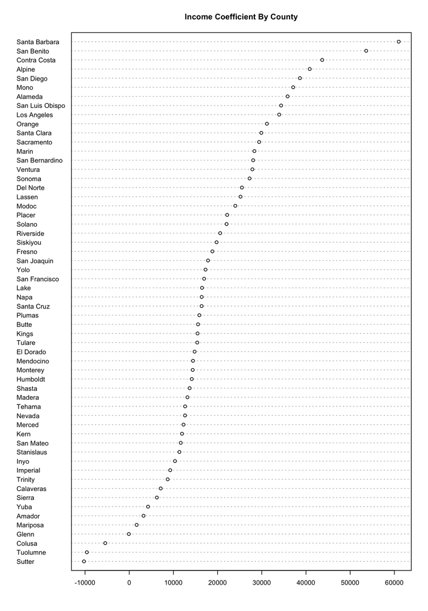

```r
#dotchart of the income variable
dotchart(sort(res['income', ]), cex=0.65, main = "Income Coefficient By County")
```

There clearly is variation in the coefficient ($beta$) for income. How does this look on a map?

First make a data.frame of the results

```r
#gotta make a df cus we have a matrix, ya know?
resdf <- data.frame(NAME=colnames(res), t(res)) #remember t = transpose

#looks good
head(resdf)
```

```
##                      NAME X.Intercept.    income  houseAge   roomhead
## Alameda           Alameda    -62373.62 35842.330  591.1001 24147.3182
## Contra Costa Contra Costa    -61759.84 43668.442  465.8897  -356.6085
## Alpine             Alpine    -77605.93 40850.588 5595.4113         NA
## Amador             Amador    120480.71  3234.519 -771.5857 37997.0069
## Butte               Butte     50935.36 15577.745 -380.5824  9078.9315
## Calaveras       Calaveras     91364.72  7126.668 -929.4065 16843.3456
##              bedroomhead population
## Alameda        129814.33  8.0570859
## Contra Costa   150662.89  0.8869663
## Alpine                NA         NA
## Amador        -194176.65  0.9971630
## Butte          -32272.68  5.7707597
## Calaveras      -78749.86  8.8865713
```

Fix the counties object. There are too many counties because of the presence of islands. I first aggregate (‘dissolve’ in GIS-speak’) the counties such that a single county becomes a single (multi-)polygon.

```r
#check dimension
dim(counties)
```

```
## [1] 68  5
```

```r
#we have multiple polygons that have the same name, let's dissolve them
dcounties <- aggregate(counties, by='NAME')
#looks like we go down to 58 counties
dim(dcounties)
```

```
## [1] 58  1
```

Now we can merge this SpatialPolygonsDataFrame with data.frame with the regression results.

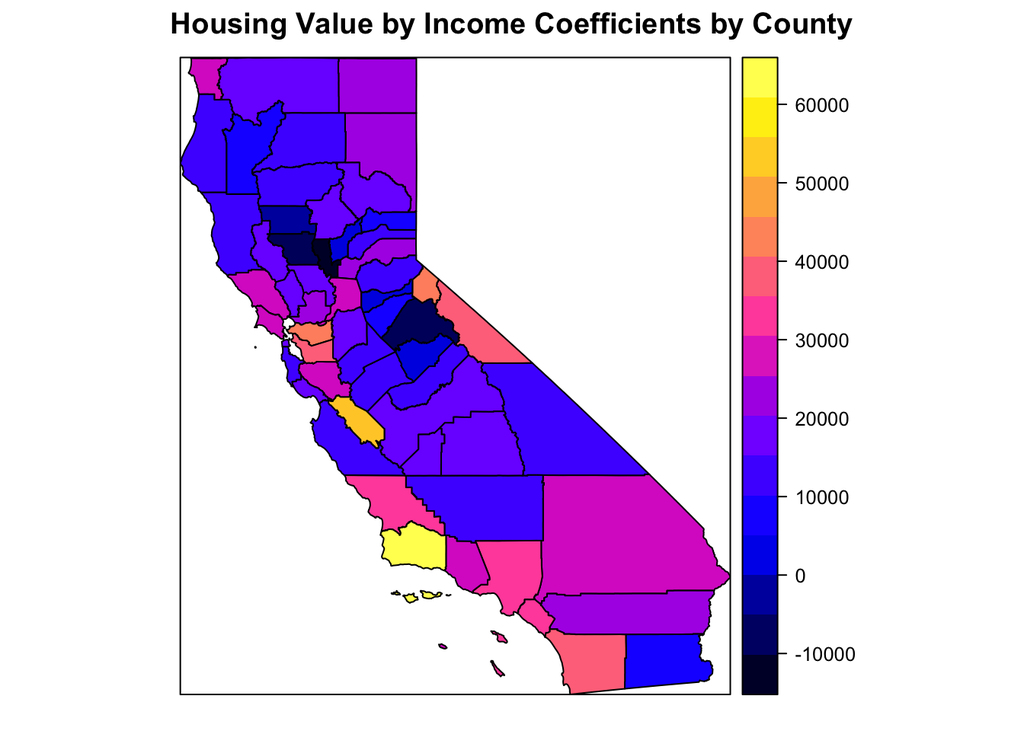

```r
#cool, merging
cnres <- merge(dcounties, resdf, by='NAME')

#map it out
spplot(cnres, 'income', main = "Housing Value by Income Coefficients by County")
```

To show all parameters in a ‘conditioning plot’, we need to first scale the values to get similar ranges.

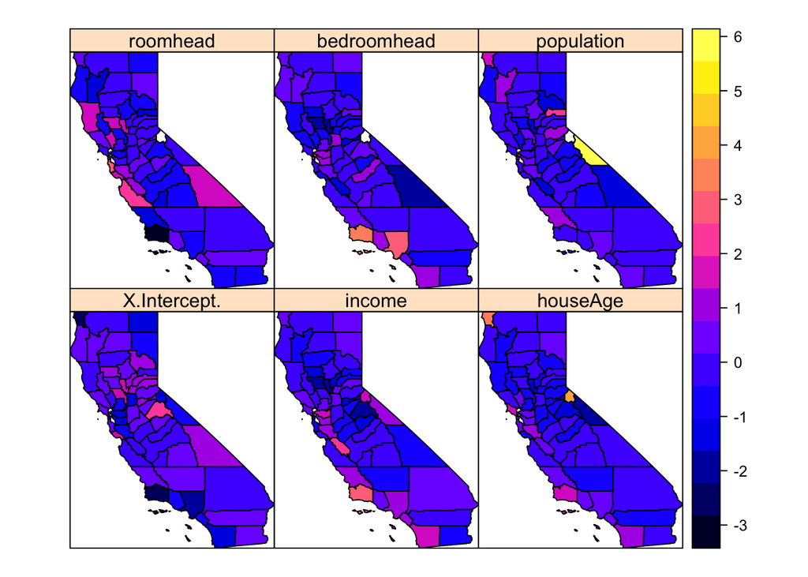

```r
# a copy of the data
cnres2 <- cnres

# scale all variables, except the first one (county name)
# assigning values to a "@data" slot is risky, but (I think) OK here
cnres2@data = data.frame(scale(data.frame(cnres)[, -1]))

#plots all variables
spplot(cnres2)
```

Is this just random noise, or is there spatial autocorrelation?

```r
#check out SA

#create nb object from cnres
nb <- poly2nb(cnres)

#create listw for moran.test
lw <- nb2listw(nb)

#moran's for income and room head
moran.test(cnres$income, lw)
```

```
##
##  Moran I test under randomisation
##
## data:  cnres$income
## weights: lw
##
## Moran I statistic standard deviate = 2.2473, p-value = 0.01231
## alternative hypothesis: greater
## sample estimates:
## Moran I statistic       Expectation          Variance
##       0.173419996      -0.017543860       0.007220867
```

```r
moran.test(cnres$roomhead, lw, na.action=na.omit)
```

```
##
##  Moran I test under randomisation
##
## data:  cnres$roomhead
## weights: lw
## omitted: 2
##
## Moran I statistic standard deviate = 1.3929, p-value = 0.08183
## alternative hypothesis: greater
## sample estimates:
## Moran I statistic       Expectation          Variance
##       0.102596252      -0.017857143       0.007478348
```

By grid cell

An alternative approach would be to compute a model for grid cells. Let’s use the ‘Teale Albers’ projection (often used when mapping the entire state of California).

```r
#proj definition
TA <- CRS("+proj=aea +lat_1=34 +lat_2=40.5 +lat_0=0 +lon_0=-120 +x_0=0
          +y_0=-4000000 +datum=NAD83 +units=m +no_defs +ellps=GRS80
          +towgs84=0,0,0")

#transform counties in TA
countiesTA <- spTransform(counties, TA)
```

Create a RasteLayer using the extent of the counties, and setting an arbitrary resolution of 50 by 50 km cells

```r
#create a raster for raster operations
r <- raster(countiesTA)

#set resolution
res(r) <- 50000
```

Get the xy coordinates for each raster cell:

```r
#xyFromCell gets lat and lon from the raster
xy <- xyFromCell(r, 1:ncell(r))
```

For each cell, we need to select a number of observations, let’s say within 50 km of the center of each cell (thus the data that are used in different cells overlap). And let’s require at least 50 observations to do a regression.

First transform the houses data to Teale-Albers

```r
#spTransform those houses
housesTA <- spTransform(houses, TA)

#get coords
crds <- coordinates(housesTA)
```

Set up a new regression function.

```r
#` function takes d and does a regression
#` different from above is d is the cells within a bandwidth while above we use a county
regfun2 <- function(d)  {
 m <- glm(houseValue~income+houseAge+roomhead+bedroomhead+population, data=d)
 coefficients(m)
}
```

Run the model for al cells if there are at least 50 observations within a radius of 50 km.

```r
#creating a list
res <- list()

#for all the coords
for (i in 1:nrow(xy)) {
    d <- sqrt((xy[i,1]-crds[,1])^2 + (xy[i,2]-crds[,2])^2) #sqrt (Xr - Xh)^2 + (Yr -Yh)^2v or the distance from each house to each raster center
    j <- which(d < 50000) #get values less than 50 km
    if (length(j) > 49) { #make sure we have at least 50 cels
        d <- hd[j,] #get the info for j
        res[[i]] <- regfun2(d) #run our function
    } else { #if less than 50, na
        res[[i]] <- NA
    }
}
```

For each cell get the income coefficient:

```r
#extract income
inc <- sapply(res, function(x) x['income'])
```

Use these values in a RasterLayer

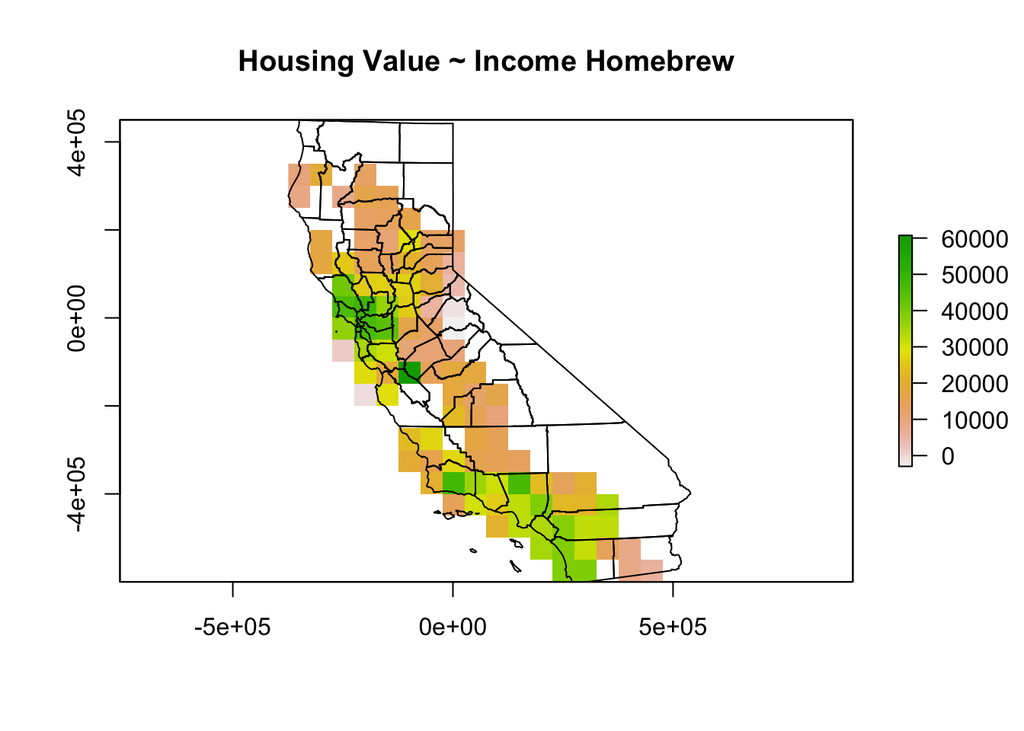

```r
#get values
rinc <- setValues(r, inc)

#plot income value
plot(rinc, main = "Housing Value ~ Income Homebrew")
plot(countiesTA, add=T)
```

```r
#get moran
Moran(rinc)
```

```
## [1] 0.3271564
```

So that was a lot of ‘home-brew-GWR’.

## 1 Strength and Weakness

**Can you comment on weaknesses (and perhaps strengths) of the approaches I have shown?**

> By County: County level data is including counties that have little housing and big area with low population, which probably gives an incomplete picture of the data, but the unit of analysis is similar, ie, county by county.

> By Raster: The raster cell analysis gives an arbitrary unit of measurement but returns a finer level of detail that allows for a more nuanced measurement that could be meaningful depending on how you define your unit of analysis.

GWR functions

Now use the spgwr package (and the the `gwr` function) to fit the model. You can do this with all data, as long as you supply and argument `fit.points` (to avoid estimating a model for each observation point. You can use a raster similar to the one I used above (perhaps disaggregate with a factor 2 first).

This is how you can get the points to use:

Create a RasterLayer with the correct extent

```r
#create a raster we did this above
r <- raster(countiesTA)
```

Set to a desired resolution. I choose 25 km

```r
#why is this different than above?
res(r) <- 25000
```

I only want cells inside of CA, so I add some more steps.

```r
#rasterize
ca <- rasterize(countiesTA, r)
```

Extract the coordinates that are not `NA`.

```r
#get fitpoints
fitpoints <- rasterToPoints(ca)
```

I don’t want the third column

```r
#get rid of column 3
fitpoints <- fitpoints[,-3]
```

```r
#this takes forever don't do it
# bw <- gwr.sel(houseValue ~ income + houseAge + rooms + bedrooms + population, data = housesTA, method = "aic", verbose = FALSE)
```

Now specify the model

```r
#gwr uses a bandwidth, which can be determined using gwr.sel but that function is extremely computationally demanding, so i used 50km
gwr.model <- gwr(houseValue ~ income + houseAge + rooms + bedrooms + population,
data = housesTA, bandwidth = 50000, fit.points = fitpoints)
```

`gwr` returns a list-like object that includes (as first element) a `SpatialPointsDataFrame` that has the model coefficients. Plot these using `spplot`, and after that, transfer them to a `RasterBrick` object.

To extract the SpatialPointsDataFrame:

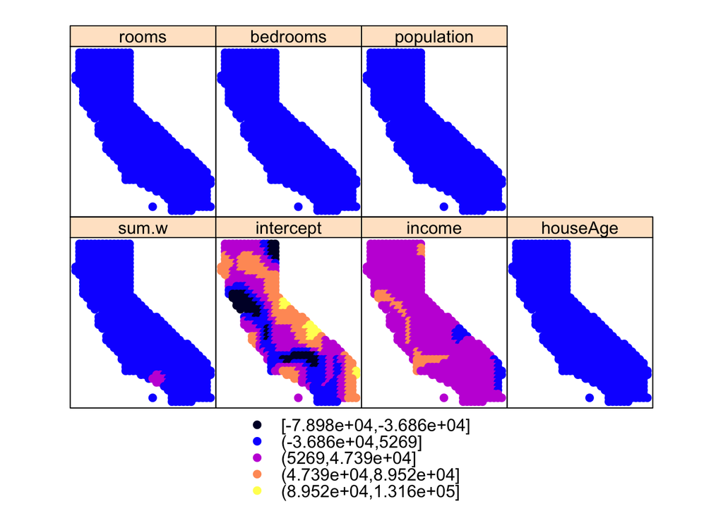

```r
#plot as an sp
#get sp data from the model
sp <- gwr.model$SDF

#rename the (Intercept)
names(sp)[2] <- "intercept"

#plot
spplot(sp)
```

To reconnect these values to the raster structure (etc.)

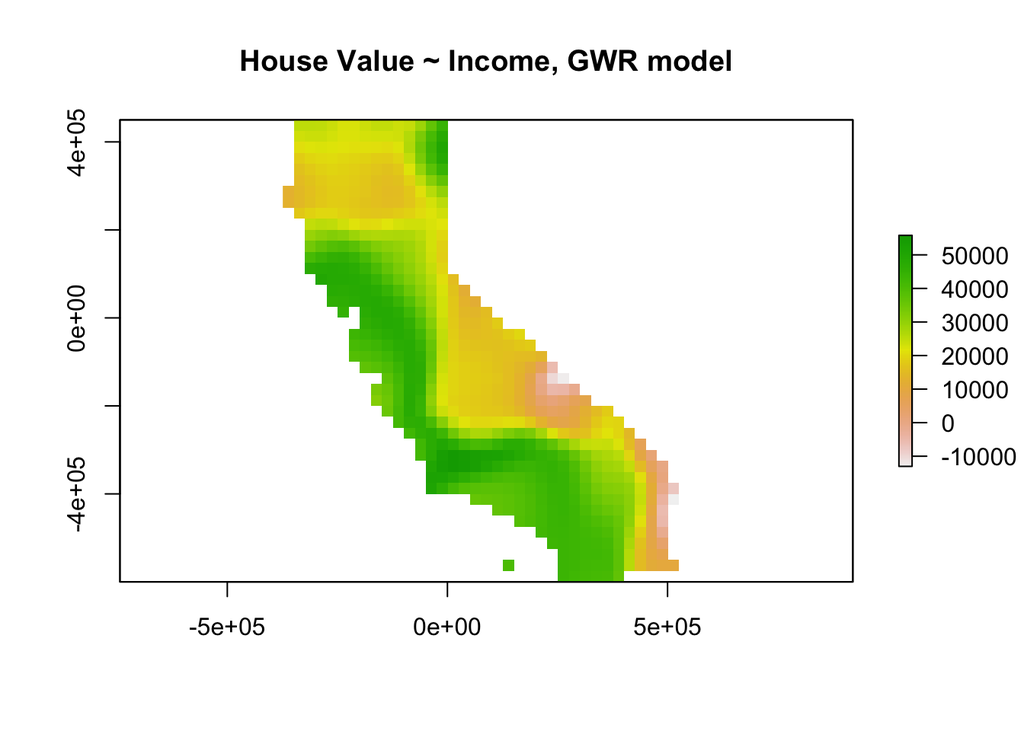

```r
#get cells from the fitpoints
cells <- cellFromXY(r, fitpoints)

#turn data in matrix
dd <- as.matrix(data.frame(sp))

#stack it like a brick
b <- brick(r, values=FALSE, nl=ncol(dd))

#fill it with the matrix data
b[cells] <- dd

#put in col names
names(b) <- colnames(dd)

#plot
plot(b$income, main = "House Value ~ Income, GWR model")
```

```r
#get morans
Moran(b$income)
```

```
## [1] 0.8399234
```

## 2 Homebrew vs SPGWR

**Briefly comment on the results and the differences (if any) with the two home-brew examples.**

> Homebrew - The homebrew for housing value ~ income shows much less smoothing, and does not cover areas in the north and in the eastern part of the state, likely due to no data in those areas that don’t have much population. There is some indication of positive spatial autocorrelation, ~0.33.

> Spgwr - The spgwr results show a much smoother map, with areas that were previously not covered in the homebrew showing low to negative values. Here we get a picture that probably looks closer to what population looks like in California. The Moran’s I is much higher, ~0.84, indicating high levels of spatial autocorrelation, which can be seen in the map.

# Wednesday

Rainfall data

Get percip data

```r
#it's in the rspatial package
d <- sp_data('precipitation')
head(d)
```

```
##      ID                 NAME   LAT    LONG ALT  JAN FEB MAR APR MAY JUN
## 1 ID741         DEATH VALLEY 36.47 -116.87 -59  7.4 9.5 7.5 3.4 1.7 1.0
## 2 ID743  THERMAL/FAA AIRPORT 33.63 -116.17 -34  9.2 6.9 7.9 1.8 1.6 0.4
## 3 ID744          BRAWLEY 2SW 32.96 -115.55 -31 11.3 8.3 7.6 2.0 0.8 0.1
## 4 ID753 IMPERIAL/FAA AIRPORT 32.83 -115.57 -18 10.6 7.0 6.1 2.5 0.2 0.0
## 5 ID754               NILAND 33.28 -115.51 -18  9.0 8.0 9.0 3.0 0.0 1.0
## 6 ID758        EL CENTRO/NAF 32.82 -115.67 -13  9.8 1.6 3.7 3.0 0.4 0.0
##   JUL  AUG SEP OCT NOV DEC
## 1 3.7  2.8 4.3 2.2 4.7 3.9
## 2 1.9  3.4 5.3 2.0 6.3 5.5
## 3 1.9  9.2 6.5 5.0 4.8 9.7
## 4 2.4  2.6 8.3 5.4 7.7 7.3
## 5 8.0  9.0 7.0 8.0 7.0 9.0
## 6 3.0 10.8 0.2 0.0 3.3 1.4
```

Compute Annual

```r
#sum monthly data
d$prec <- rowSums(d[, c(6:17)])
```

```r
#make into sp points
dsp <- SpatialPoints(d[,4:3], proj4string=CRS("+proj=longlat +datum=NAD83"))

#add in the data frame
dsp <- SpatialPointsDataFrame(dsp, d)

#county data
CA <- sp_data("counties")

#Teale Albers transformations
dta <- spTransform(dsp, TA)
cata <- spTransform(CA, TA)
```

RMSE Function

```r
#` gets the root mean squared error
#` @observed are observed values
#` @predicted are predicted values
RMSE <- function(observed, predicted) {
  sqrt(mean((predicted - observed)^2, na.rm=TRUE))
}
```

```r
#this is the null RMSE for precip data
null <- RMSE(mean(dsp$prec), dsp$prec)
null
```

```
## [1] 435.3217
```

5-fold cross validation

```r
#ensure replicatable randomness with set seet
set.seed(5132015)

#get a random assigned group for each row number in dta, k=5 is default
kf <- kfold(nrow(dta))

#create a vector with 5 NA's, will populate later
rmse <- rep(NA, 5)

#for loop that runs 5 times, k = 1 through 5
for (k in 1:5) {
  test <- dta[kf == k, ] #get test data for each k
  train <- dta[kf != k, ] #get training data for each k
  v <- voronoi(train) #get a nearest neighbor polygons for the training
  p <- extract(v, test) #extract test neightbors from the train
  rmse[k] <- RMSE(test$prec, p$prec) #get a RMSE for each k
}

rmse #show rmse for each k-fold group
```

```
## [1] 199.0686 187.8069 166.9153 191.0938 238.9696
```

```r
mean(rmse) #get the mean error of the group
```

```
## [1] 196.7708
```

```r
1 - (mean(rmse) / null) #how do the errors compare, values greater than 0 represent a decrease in error compared to the null, while 0 means the same error, while negative would be an increase in error
```

```
## [1] 0.5479875
```

## 1: Chunk Talk

**Describe what each step in the code chunk above does**

> See comments in the chunk above.

## 2: Compare Models

**How does the proximity-polygon approach compare to the NULL model?**

> Given that the difference in our error represent a 55% reduction in error, the proximity polygon approach performs better than the NULL model. As the NULL overgeneralizes precipitation data for CA.

## 3: Proximity Polygon Use

**You would not typically use proximty polygons for rainfall data. For what kind of data would you use them?**

> Categorical data, for example soil data.

IDW

```r
#get CA border
ca <- aggregate(cata)

#get only voroni polygons in the border
vca <- intersect(v, ca)

#create a raster
r <- raster(cata, res=10000)

#fill with the precip data from voroni
vr <- rasterize(vca, r, 'prec')

#run model
gs <- gstat(formula=prec~1, locations=dta)

#idw interpolation
idw <- interpolate(r, gs)
```

```
## [inverse distance weighted interpolation]
```

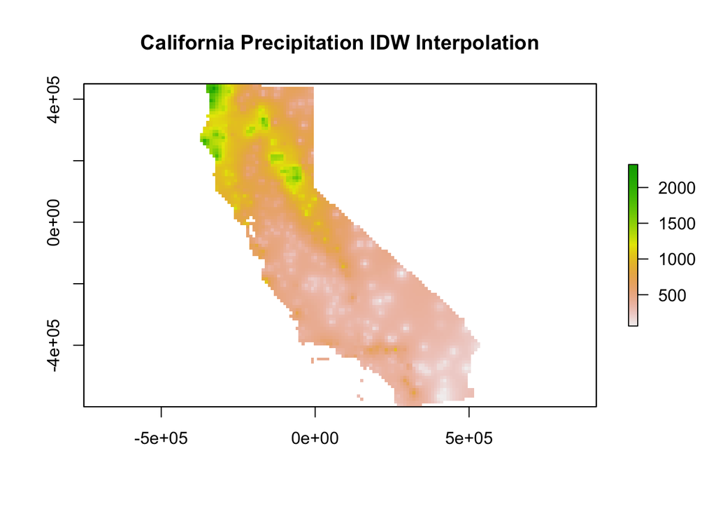

```r
#get only CA
idwr <- mask(idw, vr)
plot(idwr, main = "California Precipitation IDW Interpolation")
```

## 4: Artifacts

**IDW generated rasters tend to have a noticeable artifact. What is that?**

> Sudden low or high points on the map (artifacts) are caused by areas where there may be only one or two values, especially in this case in areas where rainfall may be zero. The IDW doesn’t provide a smoothing because of this.

```r
rmse <- rep(NA, 5) #get an empty vector
for (k in 1:5) { #k folds five
  test <- dta[kf == k, ] #set aside test data
  train <- dta[kf != k, ] #set aside train data
  gs <- gstat(formula=prec~1, locations=train) #run model
  p <- predict(gs, test) #get predictions
  rmse[k] <- RMSE(test$prec, p$var1.pred) #calculate rmse
}
```

```
## [inverse distance weighted interpolation]
## [inverse distance weighted interpolation]
## [inverse distance weighted interpolation]
## [inverse distance weighted interpolation]
## [inverse distance weighted interpolation]
```

```r
rmse
```

```
## [1] 215.3319 211.9383 190.0231 211.8308 230.1893
```

```r
mean(rmse) #get mean of rmse across folds
```

```
## [1] 211.8627
```

```r
1 - (mean(rmse) / null) #compare it to the null
```

```
## [1] 0.5133192
```

## 5: IDW Map

**Inspect the arguments used for and make a map of the IDW model below. What other name could you give to this method (IDW with these parameters)? Why?**

> Commented the arguments below.

```r
gs2 <- gstat(formula=prec~1, #prec~1 calculated the mean
             locations=dta, #locations in all dta
             nmax=1, #max near observations that will be used in the kriging prediction will be 1
             set=list(idp=1)) #sets exponent of inverse relationship to be 1
```

> This looks like a voroni polygons prediction or nearest neightbor. Since the nmax is 1 and the exponent is 1, it takes one neighbor and makes the calculation.

```r
#idw
idw2 <- interpolate(r, gs2)
```

```
## [inverse distance weighted interpolation]
```

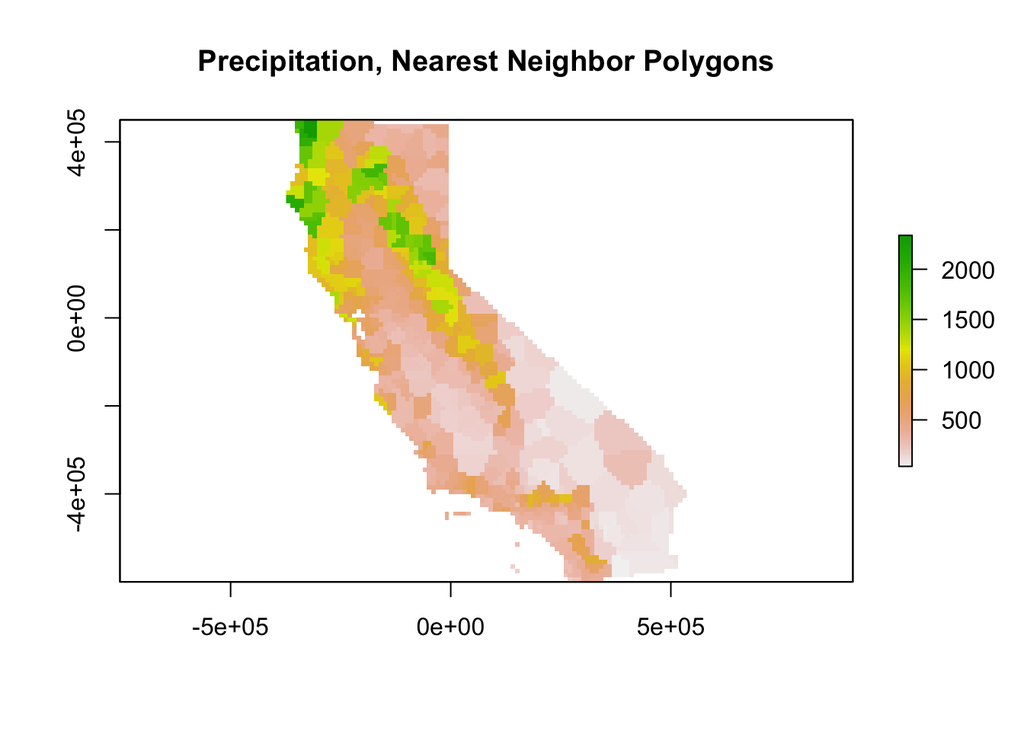

```r
#mask
idwr2 <- mask(idw2, vr)

plot(idwr2, main = "Precipitation, Nearest Neighbor Polygons")
```

Air Quality Data

```r
#get airquality data
x <- sp_data("airqual")

#make variable readable
x$OZDLYAV <- x$OZDLYAV * 1000
```

```r
#make spatial
coordinates(x) <- ~LONGITUDE + LATITUDE

#long lat projection
proj4string(x) <- CRS('+proj=longlat +datum=NAD83')

#teale albers with KM instead of M
TA <- CRS("+proj=aea +lat_1=34 +lat_2=40.5 +lat_0=0 +lon_0=-120 +x_0=0
+y_0=-4000000 +datum=NAD83 +units=km +ellps=GRS80")

#TA transformation
aq <- spTransform(x, TA)
```

```r
#CA counties
cageo <- sp_data('counties.rds')

#xform into Teale Albers KM
ca <- spTransform(cageo, TA)

#raster it
r <- raster(ca)

#set res
res(r) <- 10  # 10 km if your CRS's units are in km

#make grid
g <- as(r, 'SpatialGrid')
```

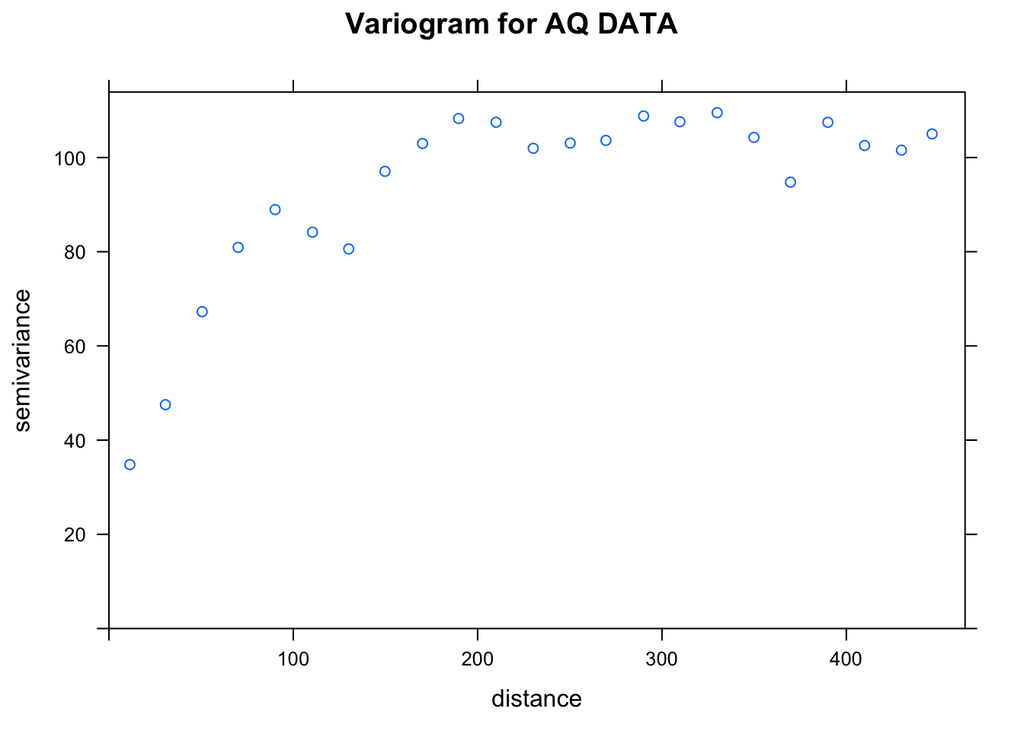

```r
#get gstat model
gs <- gstat(formula=OZDLYAV~1, locations=aq)

#get variogram
v <- variogram(gs, width=20)
plot(v, main = "Variogram for AQ DATA")
```

```r
#fit a variogram to model
fve <- fit.variogram(v, vgm(85, "Exp", 75, 20))

#looks good
fve
```

```
##   model    psill    range
## 1   Nug 21.96600  0.00000
## 2   Exp 85.52957 72.31404
```

Kriging

```r
#new gstat model using our variogram
k <- gstat(formula=OZDLYAV~1, locations=aq, model=fve)
# predicted values
kp <- predict(k, g)
```

```
## [using ordinary kriging]
```

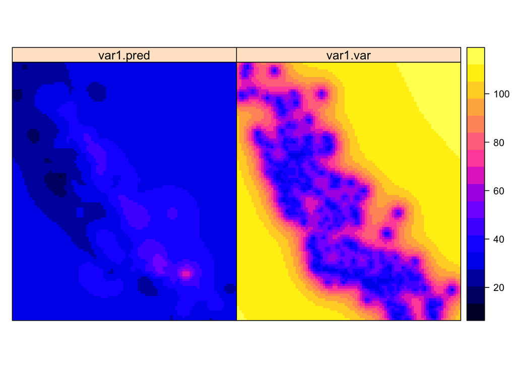

```r
#plot
spplot(kp)
```

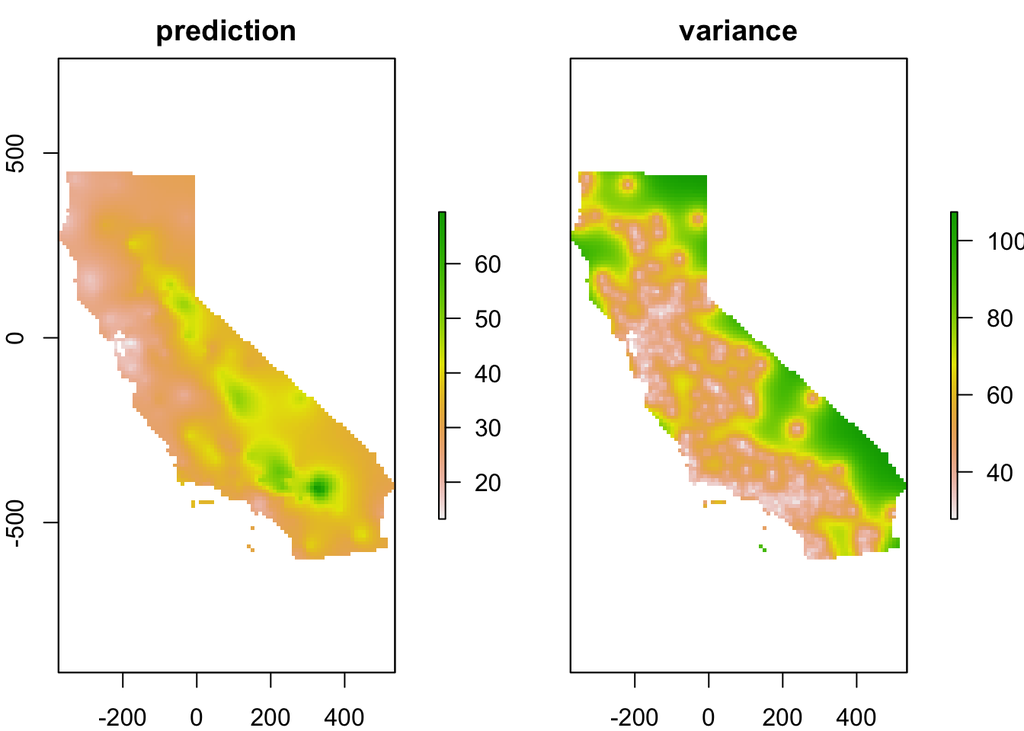

```r
#neat we have pred. and variance
ok <- brick(kp)

#mask
ok <- mask(ok, ca)

#rename
names(ok) <- c('prediction', 'variance')

plot(ok)
```

IDW

```r
#basic IDW approach
idm <- gstat(formula=OZDLYAV~1, locations=aq)

#idw interpolation
idp <- interpolate(r, idm)
```

```
## [inverse distance weighted interpolation]
```

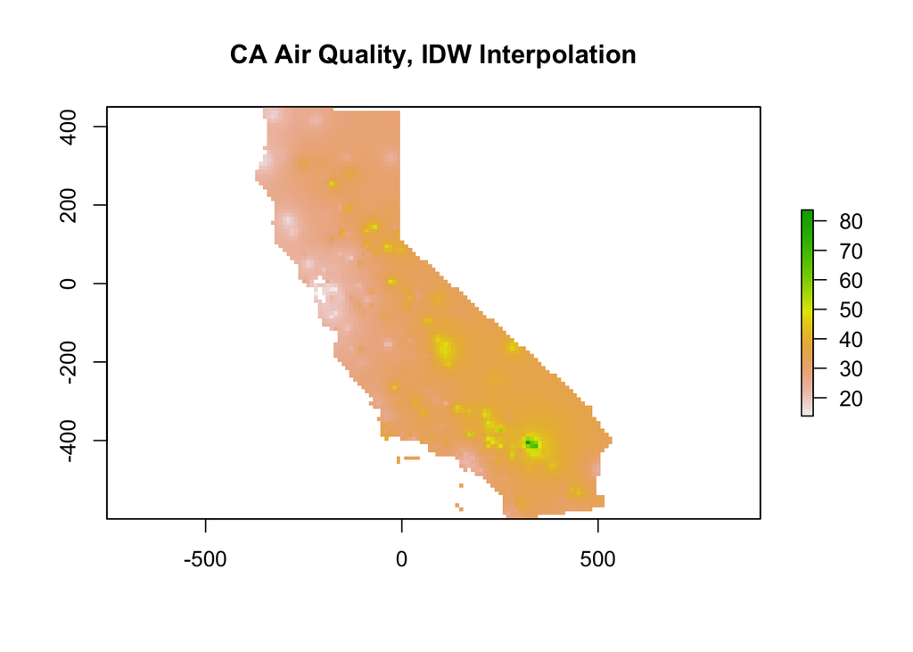

```r
#mask
idp <- mask(idp, ca)

plot(idp, main = "CA Air Quality, IDW Interpolation")
```

```r
#` gets RMSE based on test and train data from aq and from a fit based on idp
f1 <- function(x, test, train) {
  nmx <- x[1]
  idp <- x[2]
  if (nmx < 1) return(Inf)
  if (idp < .001) return(Inf)
  m <- gstat(formula=OZDLYAV~1, locations=train, nmax=nmx, set=list(idp=idp))
  p <- predict(m, newdata=test, debug.level=0)$var1.pred
  RMSE(test$OZDLYAV, p)
}
```

```r
#make replicable with consistency
set.seed(20150518)

#sample from aq to get test / train
i <- sample(nrow(aq), 0.2 * nrow(aq))
tst <- aq[i,] #test data
trn <- aq[-i,] #training data

#get the optimum (lowest)  values from our function
opt <- optim(c(8, .5), f1, test=tst, train=trn)
opt
```

```
## $par
## [1] 9.2594442 0.6817524
##
## $value
## [1] 7.861426
##
## $counts
## function gradient
##       35       NA
##
## $convergence
## [1] 0
##
## $message
## NULL
```

```r
#new model using our optimum parameters
m <- gstat(formula=OZDLYAV~1, locations=aq, nmax=opt$par[1], set=list(idp=opt$par[2]))

#idw interpolataion
idw <- interpolate(r, m)
```

```
## [inverse distance weighted interpolation]
```

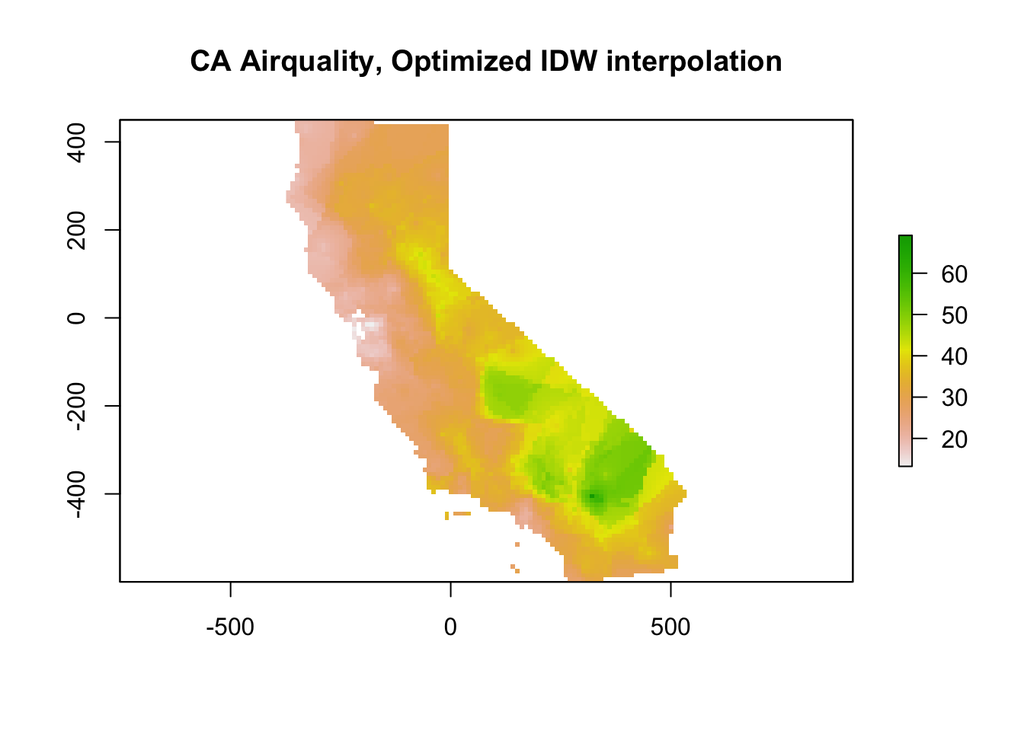

```r
#mask and plot
idw <- mask(idw, ca)
plot(idw, main = "CA Airquality, Optimized IDW interpolation")
```

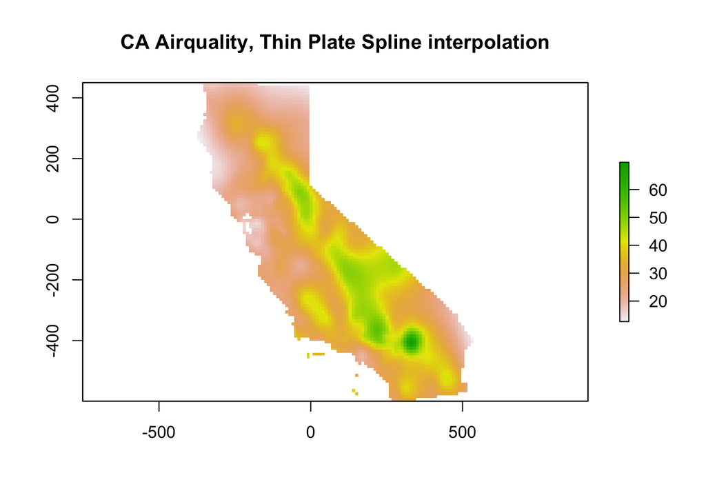

```r
#Thin plate spline model
m <- Tps(coordinates(aq), aq$OZDLYAV)

#tps interpolation
tps <- interpolate(r, m)

#mask and plot
tps <- mask(tps, idw)
plot(tps, main = "CA Airquality, Thin Plate Spline interpolation")
```

K-folding and RMSE Calculation

```r
nfolds <- 5 #5-fold crossvalidation
k <- kfold(aq, nfolds) #get k number of groups for aq data
ensrmse <- tpsrmse <- krigrmse <- idwrmse <- rep(NA, 5) #empty vectors
for (i in 1:nfolds) { #loop
  test <- aq[k!=i,] #test  (not the k group)
  train <- aq[k==i,] #train (the k group)
  m <- gstat(formula=OZDLYAV~1, locations=train, nmax=opt$par[1], set=list(idp=opt$par[2])) #idw optimum model
  p1 <- predict(m, newdata=test, debug.level=0)$var1.pred #idw prediction
  idwrmse[i] <-  RMSE(test$OZDLYAV, p1) #get RMSE
  m <- gstat(formula=OZDLYAV~1, locations=train, model=fve) #ordinary krig with the fvi variogram
  p2 <- predict(m, newdata=test, debug.level=0)$var1.pred #get OK predictions
  krigrmse[i] <-  RMSE(test$OZDLYAV, p2) #get RMSE
  m <- Tps(coordinates(train), train$OZDLYAV) #tps model
  p3 <- predict(m, coordinates(test)) #get TPS predictions
  tpsrmse[i] <-  RMSE(test$OZDLYAV, p3) #get RMSE
  w <- c(idwrmse[i], krigrmse[i], tpsrmse[i]) #get values for weighting
  weights <- w / sum(w) #assign weights for each model
  ensemble <- p1 * weights[1] + p2 * weights[2] + p3 * weights[3] #get a weighted prediction value using all the models
  ensrmse[i] <-  RMSE(test$OZDLYAV, ensemble) #get RMSE
}
#get the mean for each RMSE K-folded set
rmi <- mean(idwrmse)
rmk <- mean(krigrmse)
rmt <- mean(tpsrmse)

#get it into one vector
rms <- c(rmi, rmt, rmk)
rms
```

```
## [1] 8.041305 8.307235 7.930799
```

```r
#get mean of the ensemble
rme <- mean(ensrmse)
rme
```

```
## [1] 7.858051
```

## 6: Best Method

**Which method performed best?**

> Ordinary Kriging Performed best between the three models, with a mean RMSE of ~7.93. What’s interesting is the weighted ensemble actually outperforms the three models, with a mean RMSE of ~7.86.

Raster stack

```r
#get weights again for the ensemble
weights <- ( rms / sum(rms) )

#stack up those interpolations
s <- stack(idw, ok[[1]], tps)

#do some math, get the ensemble
ensemble <- sum(s * weights)
```

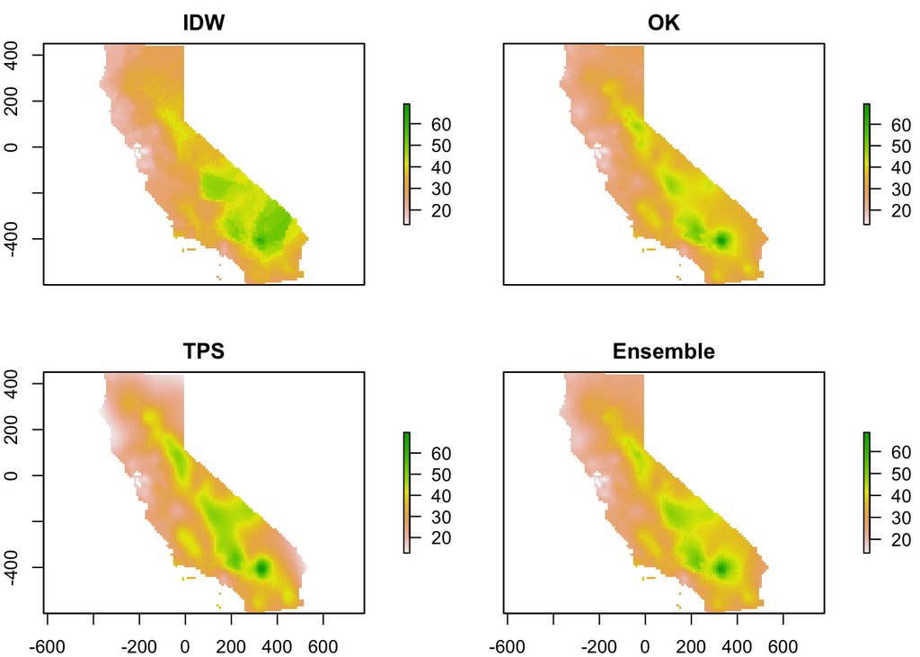

```r
#stack it up again
s <- stack(idw, ok[[1]], tps, ensemble)

#give it names
names(s) <- c('IDW', 'OK', 'TPS', 'Ensemble')

#oooooh pretty
plot(s)
```

## 7: IDW - OK

**Show where the largest difference exist between IDW and OK.**

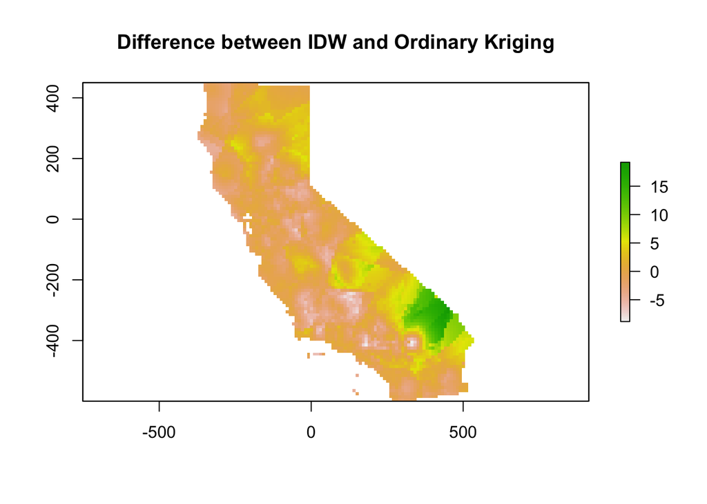

```r
#idw minus ordinary kriging
dif <- idw-ok[[1]]
plot(dif, main = "Difference between IDW and Ordinary Kriging")
```

## 8: IDW - OK 95% CI

**Show where the difference between IDW and OK is within the 95% confidence limit of the OK prediction.**

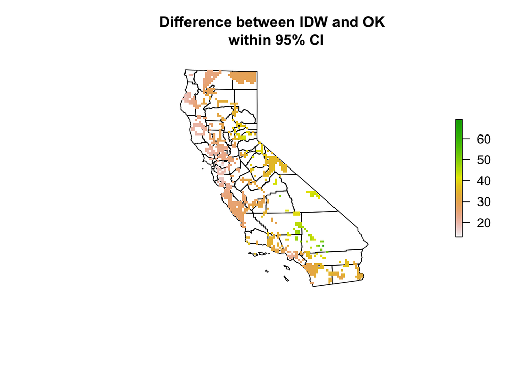

```r
#get upper and lower 95% conf interval
#` x +- 1.96 * stan dev / sqrt of n observations
upper_ok <- ok[[1]]+(1.96*(sqrt(ok[[2]])/sqrt(nrow(aq))))
lower_ok <- ok[[1]]-(1.96*(sqrt(ok[[2]])/sqrt(nrow(aq))))

#copy our idw raster
idw_diff <- idw

#take away values outside the CI
idw_diff[idw_diff>upper_ok] <- NA
idw_diff[idw_diff<lower_ok] <- NA

#plot
plot(ca, main = "Difference between IDW and OK \n within 95% CI")
plot(idw_diff, add = T)
```

## 9: Comment on Pattern

**Can you describe the pattern we are seeing, and speculate about what is causing it?**

> It looks to me like most of the 95% CI is spread out across much of the central area of the state as well as down south on the western edge. This looks to coincide with some of the observed air quality data, perhaps what is causing this pattern is areas close to observed values fall in the 95% CI.